# Quarto Technical Writing and Data Template

A Guide to References, Math, and Data Manipulation

Author

Carsten Lange (vibe-coded with Gemini)

Published

March 21, 2026

## 1 Introduction

This document serves as a template for your assignments. It demonstrates how to handle technical elements like cross-referencing, mathematical notation, and basic data manipulation using `tidyverse`.

You can refer back to the introduction using a label such as `{#sec--intro}` directly behind the section title and the reference that label in your text with `@sec-intro`. Like here: Section 1

## 2 Tables and Figures

### 2.1 Figures

To make a figure referenceable and print a caption, you must provide a label starting with `fig-` at the beginning of the code chunk options. E.g.:

`` ```{r} ``  
`#| label: fig-plot`  
`#| fig-cap: "A scatterplot of displacement vs. highway mileage using the mpg dataset."`

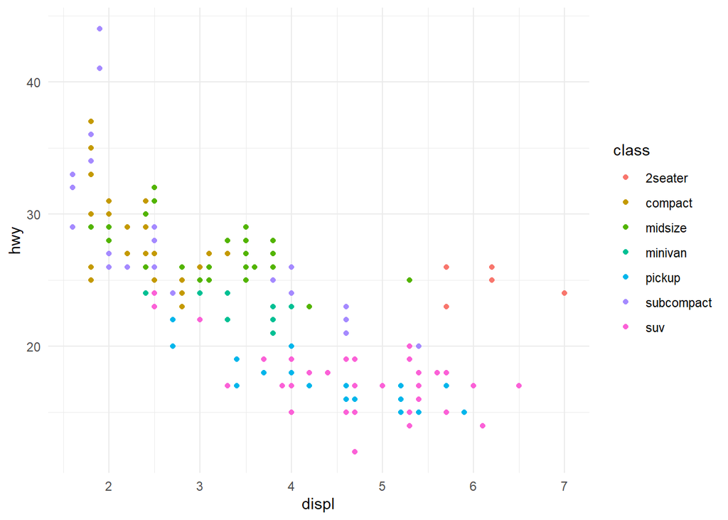

Figure 1: A scatterplot of displacement vs. highway mileage using the mpg dataset.

```r
library(tidyverse)
ggplot(mpg, aes(displ, hwy)) +
  geom_point(aes(color = class)) +
  theme_minimal()
```

As shown in Figure 1, there is a clear relationship between engine size and fuel efficiency.

### 2.2 Tables

Similarly, tables require a label starting with tbl-. We use `knitr::kable()` to format the raw data frames into clean tables for the report.

**Code Snippet:**

```r
set.seed(123)
knitr::kable(slice_sample(mpg, n=6))
```

| manufacturer | model | displ | year | cyl | trans | drv | cty | hwy | fl | class |
| --- | --- | --- | --- | --- | --- | --- | --- | --- | --- | --- |
| pontiac | grand prix | 5.3 | 2008 | 8 | auto(s4) | f | 16 | 25 | p | midsize |
| toyota | toyota tacoma 4wd | 4.0 | 2008 | 6 | auto(l5) | 4 | 16 | 20 | r | pickup |
| toyota | 4runner 4wd | 4.7 | 2008 | 8 | auto(l5) | 4 | 14 | 17 | r | suv |
| audi | a4 quattro | 3.1 | 2008 | 6 | auto(s6) | 4 | 17 | 25 | p | compact |
| toyota | corolla | 1.8 | 1999 | 4 | auto(l4) | f | 24 | 33 | r | compact |
| subaru | impreza awd | 2.5 | 2008 | 4 | auto(s4) | 4 | 20 | 25 | p | compact |

The raw data values are detailed in Table 1.

## 3 Mathematical Notation

### 3.1 Inline Math

To include math within a sentence, wrap the LaTeX code in single dollar signs $. For example, the sample mean is defined as $\bar{x} = \frac{\sum x_i}{n}$.

Note: Do not leave spaces between the $ and your math code (e.g., use $x$, not $ x $).

### 3.2 Display Math

For equations on their own line, use double dollar signs $$.

$$f(x) = \frac{1}{\sigma\sqrt{2\pi}} e^{-\frac{1}{2}\left(\frac{x-\mu}{\sigma}\right)^2}$$

To number and reference an equation, add a label starting with `#eq-` in curly braces immediately after the closing $$. Start a new line for each $$. E.g.:

`$$`
`E = mc^2`
`$$ {#eq-einstein}`

$$E = mc^2
\tag{1}$$

We can see the **relationship** between *energy* and *mass* in Equation 1.

## 4 Data Manipulation with tidyverse

### 4.1 Grouping and Summarizing

Use `group_by()` to categorize data and `summarize()` to calculate aggregate statistics (like mean, sum, or count) for those categories.

```r
library(tidyverse)

AggregatedMPG=mpg |>
  group_by(class) |>
  summarize(miles_per_gallon_hwy = mean(hwy),
    observations = n()
  )
  knitr::kable(AggregatedMPG)
```

Table 2: Average Highway Mileage and Count by Vehicle Class.

| class | miles_per_gallon_hwy | observations |
| --- | --- | --- |
| 2seater | 24.80000 | 5 |
| compact | 28.29787 | 47 |
| midsize | 27.29268 | 41 |
| minivan | 22.36364 | 11 |
| pickup | 16.87879 | 33 |
| subcompact | 28.14286 | 35 |
| suv | 18.12903 | 62 |

The summary statistics in Table 2 show how mileage varies by vehicle type.

### 4.2 Left Join

A `left_join()` merges two tables. It keeps every row from the “left” (first) table and adds columns from the “right” (second) table where the keys match.

```r
# Create example data frames
students <- data.frame(
  student_id = c(101, 102, 103),
  name = c("Alice", "Bob", "Charlie")
)
knitr::kable(students)
```

Table 3: Student Data (left table)

| student_id | name |
| --- | --- |
| 101 | Alice |
| 102 | Bob |
| 103 | Charlie |

```r
grades <- data.frame(
  student_id = c(101, 102),
  grade = c("A", "B")
)
knitr::kable(grades)
```

Table 4: Grades Data (right table)

| student_id | grade |
| --- | --- |
| 101 | A |
| 102 | B |

```r
# Perform the join
students_with_grades =  left_join(students, grades, by = c("student_id" = "student_id"))
knitr::kable(students_with_grades)
```

Table 5: Students with their grades (joined table)

| student_id | name | grade |
| --- | --- | --- |
| 101 | Alice | A |
| 102 | Bob | B |
| 103 | Charlie | NA |

### 4.3 Important Reminders for Students:

- **Labels:** Labels for references (e.g., `#fig-`, `#tbl-`) **must** be inside the code chunk options (the lines starting with `#|`).
- **Indentation:** In the YAML header at the top, indentation is strictly enforced. Ensure there are two spaces for each level.